# Writing Functions in R

7/21/2020

## Hello!

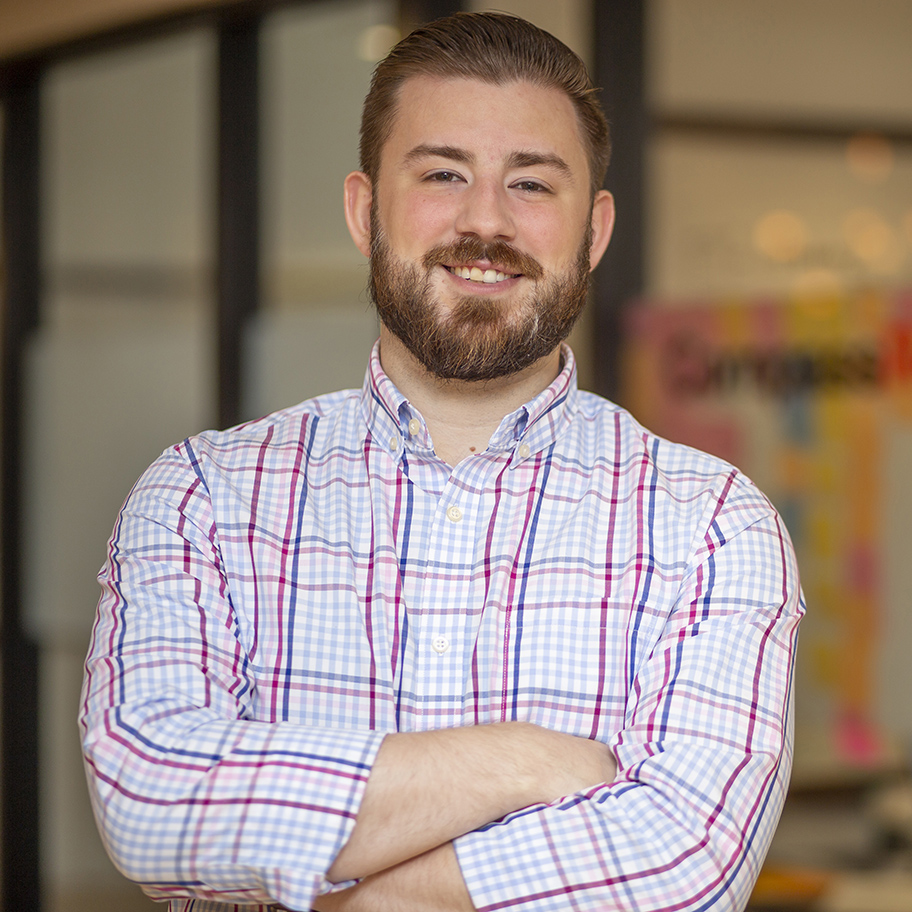

#### @rharrington31

#### Lead Data Scientist @

[figure not shown]

#### Co-founder @

[figure not shown]

## Goal

Understand how to write functions in R

### Questions we’ll answer…

- What are the basic parts of a function?
- How do we handle instances where functions might fail?
- How do we create functions within the [tidyverse](https://www.tidyverse.org/) framework?

## Solving a problem

In order to explore writing functions, we’ll consider the question:

### How can we use COVID-19 data in relation to Delaware?

Specifically, we’ll be using the data that powers the [Johns Hopkins Coronavirus Resource Center dashboard](https://coronavirus.jhu.edu/map.html).

All of the raw data is available from [Github](https://github.com/CSSEGISandData/COVID-19)

All of the code for this workshop is also available on [Github](https://github.com/rharrington31/functions_workshop)

## Why write a function?

- Repeatability
- Readability
- Generalizability
- Consistency

## When to write a function?

> When you’ve written the same code 3 times, write a function  
> When you’ve given the same in-person advice 3 times, write a blog post

> — David Robinson (@drob) [November 9, 2017](https://twitter.com/drob/status/928447584712253440?ref_src=twsrc%5Etfw)

## How do we write a function?

```r
function_name <- function(arg1, arg2, ...) {

  # Your code here!

  return(something)

}
```

- `function_name`: the name of your function that you will use moving forward
- `arg1, arg2`: the **arguments** or **parameters** that will be required to execute your function
- `...`: allows you to pass arguments that you haven’t explicitly named to your function
- `{}`: function body; where your code goes
- `return`: an object that gets returned back to the global environment

## Good names and… less good names

Your function names should be descriptive. Verbs are your friend.

```r
## Good
get_county

## ...less good
gc
```

## Good names and… less good names

Don’t use names that already exist.

```r
## Good
read_covid_data

## ...less good
read_csv
```

## Good names and… less good names

```r
## Good
graph_covid

## ...less good
graphCovid
```

## What do arguments look like in practice?

- You can create functions with no arguments or as many arguments as you’d like
- You can provide an argument with a default value
- Arguments do not need to be named explicitly
- Arguments are evaluated lazily

## The … argument

This works well for times where you will want to pass additional arguments to another function inside of the function you are writing

```r
get_mean <- function(list, ...) {

  mean(list, ...)

}
```

```r
items <- 1:100

get_mean(items)
```

```
## [1] 50.5
```

## The … argument

This works well for times where you will want to pass additional arguments to another function inside of the function you are writing

```r
items_with_na <- c(1:100, NA)
get_mean(items_with_na)
```

```
## [1] NA
```

```r
get_mean(items_with_na, na.rm = T)
```

```
## [1] 50.5
```

## How do we `return` values?

Counter-intuitively, we **do not** need to explicitly write `return` at the end of every function that we write.

R automatically returns the result of the last evaluated expression. In fact, it is considered best practice to *only* write `return` when we do so early within a function.

Functions can only `return` one object back to the global environment. However, we can get around this by storing objects to a `list` and then returning the `list.